# Project: WeRateDogs Data Analysis

## Introduction

The dataset that you will be wrangling (and analyzing and visualizing) is the tweet archive of Twitter user @dog_rates, also known as WeRateDogs. WeRateDogs is a Twitter account that rates people's dogs with a humorous comment about the dog. These ratings almost always have a denominator of 10. The numerators, though? Almost always greater than 10. 11/10, 12/10, 13/10, etc. Why? Because "they're good dogs Brent." WeRateDogs has over 4 million followers and has received international media coverage.

WeRateDogs downloaded their Twitter archive and sent it to Udacity via email exclusively for you to use in this project. This archive contains basic tweet data (tweet ID, timestamp, text, etc.) for all 5000+ of their tweets as they stood on August 1, 2017.

```python
#import libraries
import pandas as pd
import numpy as np
import seaborn as sb
import matplotlib.pyplot as plt
% matplotlib inline
```

```python
# Read and check the twitter archive
twitter_archive = pd.read_csv('twitter-archive-enhanced.csv')
twitter_archive.head(3)
```

|  | tweet_id | in_reply_to_status_id | in_reply_to_user_id | timestamp | source | text | retweeted_status_id | retweeted_status_user_id | retweeted_status_timestamp | expanded_urls | rating_numerator | rating_denominator | name | doggo | floofer | pupper | puppo |
| --- | --- | --- | --- | --- | --- | --- | --- | --- | --- | --- | --- | --- | --- | --- | --- | --- | --- |
| 0 | 892420643555336193 | NaN | NaN | 2017-08-01 16:23:56 +0000 | <a href="http://twitter.com/download/iphone" r... | This is Phineas. He's a mystical boy. Only eve... | NaN | NaN | NaN | https://twitter.com/dog_rates/status/892420643... | 13 | 10 | Phineas | None | None | None | None |
| 1 | 892177421306343426 | NaN | NaN | 2017-08-01 00:17:27 +0000 | <a href="http://twitter.com/download/iphone" r... | This is Tilly. She's just checking pup on you.... | NaN | NaN | NaN | https://twitter.com/dog_rates/status/892177421... | 13 | 10 | Tilly | None | None | None | None |
| 2 | 891815181378084864 | NaN | NaN | 2017-07-31 00:18:03 +0000 | <a href="http://twitter.com/download/iphone" r... | This is Archie. He is a rare Norwegian Pouncin... | NaN | NaN | NaN | https://twitter.com/dog_rates/status/891815181... | 12 | 10 | Archie | None | None | None | None |

```python
# Programmatically download the dog image prediction files from
# the Udacity server using Request library

# Reference : http://docs.python-requests.org/en/master/user/quickstart/#response-content
# Reference : https://docs.python.org/3/library/os.path.html
# Reference : https://docs.python.org/3/library/os.html?highlight=makedirs#os.makedirs
# Reference : https://stat.ethz.ch/pipermail/r-devel/2012-August/064739.html
# Reference : https://docs.python.org/3/tutorial/inputoutput.html

# import the os library for accessing filesystem
import os
# import the request module which allows us to send organic, grass-fed HTTP/1.1 requests without manual labor
import requests

# Save to a file called folder_name
folder_name = 'image-predictions'

# Make sure the file existed
# Check if the file is not existed which return True then it will execute Recursive directory creation function.
# Like mkdir(), but makes all intermediate-level directories needed to contain the leaf directory.
if not os.path.exists(folder_name) :
    os.makedirs(folder_name)

url = 'https://d17h27t6h515a5.cloudfront.net/topher/2017/August/599fd2ad_image-predictions/image-predictions.tsv'

# Get the webpage from url. Now , we have a response object called response
response = requests.get(url)

# Open() returns the file object which is
# a file which Join folder_name and url path components intelligently  then
# writes the contents of response to the file, returning the number of characters written.
with open(os.path.join(folder_name , url.split('/')[-1]) , mode = 'wb') as file :
    file.write(response.content)
```

```python
#open tsv file
images = pd.read_table('image-predictions/image-predictions.tsv',
                       sep='\t')
```

```python
images.head(2)
```

|  | tweet_id | jpg_url | img_num | p1 | p1_conf | p1_dog | p2 | p2_conf | p2_dog | p3 | p3_conf | p3_dog |
| --- | --- | --- | --- | --- | --- | --- | --- | --- | --- | --- | --- | --- |
| 0 | 666020888022790149 | https://pbs.twimg.com/media/CT4udn0WwAA0aMy.jpg | 1 | Welsh_springer_spaniel | 0.465074 | True | collie | 0.156665 | True | Shetland_sheepdog | 0.061428 | True |
| 1 | 666029285002620928 | https://pbs.twimg.com/media/CT42GRgUYAA5iDo.jpg | 1 | redbone | 0.506826 | True | miniature_pinscher | 0.074192 | True | Rhodesian_ridgeback | 0.072010 | True |

## Retrieve tweets from Twitter API

Use Python's Tweepy Library to query Twitter API for each tweet's JSON data. Then, store each tweet's JSON data into a file

```python
# Ref : http://www.tweepy.org
# Ref : https://developer.twitter.com/en/docs/basics/developer-portal/overview
# Ref : https://stackoverflow.com/questions/28384588/twitter-api-get-tweets-with-specific-id
import tweepy
from tweepy import OAuthHandler
import json
import csv
import sys
import os
import time

# authentication
consumer_key = ''
consumer_secret = ''
access_token = ''
access_secret = ''

auth = tweepy.OAuthHandler(consumer_key , consumer_secret)
auth.set_access_token(access_token , access_secret)

api = tweepy.API(auth_handler = auth ,
                wait_on_rate_limit = True ,
                wait_on_rate_limit_notify = True)
```

```python
# So now we are ready to start the process.
# We create the list of ids that we gonna use to fetch the required tweets.
# We use the ids of the twitter_archive DataFrame:
list_of_ids_in_twittter_archive = twitter_archive['tweet_id'].tolist()
```

```python
# We then fetch all tweets from the twitter API using the following loop:
list_of_tweets = []
# Tweets that can't be found are saved in the list below:
cant_find_tweets_for_those_ids = []
for each_id in list_of_ids_in_twittter_archive:
    try:
        start = time.time()
        list_of_tweets.append(api.get_status(each_id))
        end = time.time()
        print(end - start)
    except Exception as e:
        cant_find_tweets_for_those_ids.append(each_id)
        print(str(each_id))
```

[output not shown]

[output cut: 845 more lines]

[output not shown]

[output not shown]

[output not shown]

[output cut: 845 more lines]

[output not shown]

[output not shown]

[output not shown]

[output cut: 501 more lines]

[output not shown]

```python
# Then in this code block we isolate the json part of each tweepy status object
# that we have downloaded and we add them all into a list....
my_list_of_dicts = []
for each_json_tweet in list_of_tweets:
    my_list_of_dicts.append(each_json_tweet._json)
#...and then we write this list into a txt file:
with open('tweet_json.txt', 'w') as file:
        file.write(json.dumps(my_list_of_dicts, indent=4))
```

```python
# Twitter Query using twitter_id information from twitter_archive

# Ref for rate limit - https://developer.twitter.com/en/docs/basics/rate-limiting
# Ref for Measuring time elapsed in Python(code timer) - https://stackoverflow.com/questions/7370801/measure-time-elapsed-in-python
# Ref for Completely open API - https://github.com/siznax/wptools/wiki
# Ref for try-except blocks - https://wiki.python.org/moin/HandlingExceptions
# Ref for Reading and Writing JSON to a file in Python - https://stackabuse.com/reading-and-writing-json-to-a-file-in-python/
# Now we are going to create a DataFrame from the tweet_json.txt file:
my_demo_list = []
with open('tweet_json.txt', encoding='utf-8') as json_file:
    all_data = json.load(json_file)
    for each_dictionary in all_data:
        tweet_id = each_dictionary['id']
        whole_tweet = each_dictionary['text']
        only_url = whole_tweet[whole_tweet.find('https'):]
        favorite_count = each_dictionary['favorite_count']
        retweet_count = each_dictionary['retweet_count']
        created_at = each_dictionary['created_at']
        whole_source = each_dictionary['source']
        only_device = whole_source[whole_source.find('rel="nofollow">') + 15:-4]
        source = only_device
        retweeted_status = each_dictionary['retweeted_status'] = each_dictionary.get('retweeted_status', 'Original tweet')
        if retweeted_status == 'Original tweet':
            url = only_url
        else:
            retweeted_status = 'This is a retweet'
            url = 'This is a retweet'

        my_demo_list.append({'tweet_id': str(tweet_id),
                             'favorite_count': int(favorite_count),
                             'retweet_count': int(retweet_count),
                             'url': url,
                             'created_at': created_at,
                             'source': source,
                             'retweeted_status': retweeted_status,
                            })
        tweet_json = pd.DataFrame(my_demo_list, columns = ['tweet_id', 'favorite_count',
                                                       'retweet_count', 'created_at',
                                                       'source', 'retweeted_status', 'url'])
```

# Data Wrangling

## Assess

Identify Quality and tidiness issues visually and programmatically. Assess ,Clean and Test at least (8) Quality issues and at least (2) tidiness issues

```python
twitter_archive.info()
```

```
<class 'pandas.core.frame.DataFrame'>
RangeIndex: 2356 entries, 0 to 2355
Data columns (total 17 columns):
tweet_id                      2356 non-null int64
in_reply_to_status_id         78 non-null float64
in_reply_to_user_id           78 non-null float64
timestamp                     2356 non-null object
source                        2356 non-null object
text                          2356 non-null object
retweeted_status_id           181 non-null float64
retweeted_status_user_id      181 non-null float64
retweeted_status_timestamp    181 non-null object
expanded_urls                 2297 non-null object
rating_numerator              2356 non-null int64
rating_denominator            2356 non-null int64
name                          2356 non-null object
doggo                         2356 non-null object
floofer                       2356 non-null object
pupper                        2356 non-null object
puppo                         2356 non-null object
dtypes: float64(4), int64(3), object(10)
memory usage: 313.0+ KB
```

1. What the hell is doggo, floofer , pupper and puppo maybe it should be in integer or boolean
2. Not all have same number of entries , a lot of null values

```python
images.info()
```

```
<class 'pandas.core.frame.DataFrame'>
RangeIndex: 2075 entries, 0 to 2074
Data columns (total 12 columns):
tweet_id    2075 non-null int64
jpg_url     2075 non-null object
img_num     2075 non-null int64
p1          2075 non-null object
p1_conf     2075 non-null float64
p1_dog      2075 non-null bool
p2          2075 non-null object
p2_conf     2075 non-null float64
p2_dog      2075 non-null bool
p3          2075 non-null object
p3_conf     2075 non-null float64
p3_dog      2075 non-null bool
dtypes: bool(3), float64(3), int64(2), object(4)
memory usage: 152.1+ KB
```

### Quality Issues - commonly referred to as dirty data. Dirty data has issues with its content. Issues that only requires you to remove rows or columns or to update values to fix them (and does not require you to change the structure of the columns) are hence should be considered Quality issues.

In twitter_archive table, there are a lot of names that should not be included in the Names Column. We can cross-reference the text data with Names Column.

retweet_status : this variable provide the source tweet which provides us information about the status of the tweets and can be use to identify tweets that are retweets.

In twitter_archive table , Date and Time columns need to be converted to datetime objects.

In twitter_archive table , drop the inessential columns to reduce confusion.

The date, time and stage columns should be near the front columns for easy read in twitter_archive_clean

tweet_id has an integer datatype when it is not numeric in twitter_archive_clean

date and time columns has to change the datatypes to time-related datatypes in twitter_archive_clean

If the rating_numerator or rating_denominator have decimal values , it could not work in twitter_archive_clean

In tweet_json table, rename the id column to "tweet_id" to match the other 2 tables for merging purposes.

In twitter_json table , convert id column from a number to a string

Inessential underscore in p1,p2,p3 columns in images table

Some of the text in p1, p2, p3 columns has big letter and some has small letter. Making the data harder to analyse

The datatypes of tweet_id in twitter_archive_clean and tweet_json_clean is string while for images_clean is integer

The 3 datasets are discrete and confusing when we need to analyze the different correlation in each dataset

There is time info in the Time column that is unessential when the data is being retrieved using Twitter API

Inessential column called 'Unnamed:0'

### Tidiness Issues - commonly referred to as messy data. Messy data has issues with its structure.

In twitter_archive table, each dog stage should forms a columns not few different columns for doggo, fluffer, pupper, puppo .

In twitter_archive table, the date and time are put into one column instead it should be split into two different columns

## Clean

```python
# Copy the dataframes to avoid from causing unwanted data loss in the original dataframe
twitter_archive_clean = twitter_archive.copy()
images_clean = images.copy()
tweet_json_clean = tweet_json.copy()
```

#### Problem

In twitter_archive table, there are a lot of names that should not be included in the Names Column. We can cross-reference the text data with Names Column.

#### Define

Replace the name with correct names or replace it as a None value

#### Code

```python
# Replace the name with correct names or replace it as a None value (Based on your opinion , this should be
# Drop rather than replace, try dig deeper to understand later)

# Ref : https://pandas.pydata.org/pandas-docs/stable/generated/pandas.DataFrame.replace.html

twitter_archive_clean['name'].replace('the' , 'None' , inplace = True)
twitter_archive_clean['name'].replace('light' , 'None' , inplace = True)
twitter_archive_clean['name'].replace('life' , 'None' , inplace = True)
twitter_archive_clean['name'].replace('an' , 'None' , inplace = True)
twitter_archive_clean['name'].replace('a' , 'None' , inplace = True)
twitter_archive_clean['name'].replace('by' , 'None' , inplace = True)
twitter_archive_clean['name'].replace('actually' , 'None' , inplace = True)
twitter_archive_clean['name'].replace('just' , 'None' , inplace = True)
twitter_archive_clean['name'].replace('getting' , 'None' , inplace = True)
twitter_archive_clean['name'].replace('infuriating' , 'None' , inplace = True)
twitter_archive_clean['name'].replace('old' , 'None' , inplace = True)
twitter_archive_clean['name'].replace('all' , 'None' , inplace = True)
twitter_archive_clean['name'].replace('this' , 'None' , inplace = True)
twitter_archive_clean['name'].replace('very' , 'None' , inplace = True)
twitter_archive_clean['name'].replace('mad' , 'None' , inplace = True)
twitter_archive_clean['name'].replace('not' , 'None' , inplace = True)
twitter_archive_clean['name'].replace('one' , 'None' , inplace = True)
twitter_archive_clean['name'].replace('my' , 'None' , inplace = True)
twitter_archive_clean['name'].replace('O' , "O'Malley" , inplace = True)
twitter_archive_clean['name'].replace('quite' , 'None' , inplace = True)
twitter_archive_clean['name'].replace('such' , 'None' , inplace = True)
```

#### Test

```python
twitter_archive_clean.head(5)
```

|  | tweet_id | in_reply_to_status_id | in_reply_to_user_id | timestamp | source | text | retweeted_status_id | retweeted_status_user_id | retweeted_status_timestamp | expanded_urls | rating_numerator | rating_denominator | name | doggo | floofer | pupper | puppo |
| --- | --- | --- | --- | --- | --- | --- | --- | --- | --- | --- | --- | --- | --- | --- | --- | --- | --- |
| 0 | 892420643555336193 | NaN | NaN | 2017-08-01 16:23:56 +0000 | <a href="http://twitter.com/download/iphone" r... | This is Phineas. He's a mystical boy. Only eve... | NaN | NaN | NaN | https://twitter.com/dog_rates/status/892420643... | 13 | 10 | Phineas | None | None | None | None |
| 1 | 892177421306343426 | NaN | NaN | 2017-08-01 00:17:27 +0000 | <a href="http://twitter.com/download/iphone" r... | This is Tilly. She's just checking pup on you.... | NaN | NaN | NaN | https://twitter.com/dog_rates/status/892177421... | 13 | 10 | Tilly | None | None | None | None |
| 2 | 891815181378084864 | NaN | NaN | 2017-07-31 00:18:03 +0000 | <a href="http://twitter.com/download/iphone" r... | This is Archie. He is a rare Norwegian Pouncin... | NaN | NaN | NaN | https://twitter.com/dog_rates/status/891815181... | 12 | 10 | Archie | None | None | None | None |
| 3 | 891689557279858688 | NaN | NaN | 2017-07-30 15:58:51 +0000 | <a href="http://twitter.com/download/iphone" r... | This is Darla. She commenced a snooze mid meal... | NaN | NaN | NaN | https://twitter.com/dog_rates/status/891689557... | 13 | 10 | Darla | None | None | None | None |
| 4 | 891327558926688256 | NaN | NaN | 2017-07-29 16:00:24 +0000 | <a href="http://twitter.com/download/iphone" r... | This is Franklin. He would like you to stop ca... | NaN | NaN | NaN | https://twitter.com/dog_rates/status/891327558... | 12 | 10 | Franklin | None | None | None | None |

#### Problem

retweet_status : this variable provide the source tweet which provides us information about the status of the tweets and can be use to identify tweets that are retweets.

#### Define

Identify and drop the tweets that have a retweeted_status because those are not original

#### Code

```python
# Identify the tweets that have a retweeted_status columns
twitter_archive_clean['retweeted_status_id'].head(5)
```

```
0   NaN
1   NaN
2   NaN
3   NaN
4   NaN
Name: retweeted_status_id, dtype: float64
```

```python
# Show the tweets that have a retweeted_status columns

# Ref : https://pandas.pydata.org/pandas-docs/version/0.23.4/generated/pandas.isnull.html
twitter_archive_clean[twitter_archive_clean['retweeted_status_id'].isnull() == False]
```

|  | tweet_id | in_reply_to_status_id | in_reply_to_user_id | timestamp | source | text | retweeted_status_id | retweeted_status_user_id | retweeted_status_timestamp | expanded_urls | rating_numerator | rating_denominator | name | doggo | floofer | pupper | puppo |
| --- | --- | --- | --- | --- | --- | --- | --- | --- | --- | --- | --- | --- | --- | --- | --- | --- | --- |
| 19 | 888202515573088257 | NaN | NaN | 2017-07-21 01:02:36 +0000 | <a href="http://twitter.com/download/iphone" r... | RT @dog_rates: This is Canela. She attempted s... | 8.874740e+17 | 4.196984e+09 | 2017-07-19 00:47:34 +0000 | https://twitter.com/dog_rates/status/887473957... | 13 | 10 | Canela | None | None | None | None |
| 32 | 886054160059072513 | NaN | NaN | 2017-07-15 02:45:48 +0000 | <a href="http://twitter.com/download/iphone" r... | RT @Athletics: 12/10 #BATP https://t.co/WxwJmv... | 8.860537e+17 | 1.960740e+07 | 2017-07-15 02:44:07 +0000 | https://twitter.com/dog_rates/status/886053434... | 12 | 10 | None | None | None | None | None |
| 36 | 885311592912609280 | NaN | NaN | 2017-07-13 01:35:06 +0000 | <a href="http://twitter.com/download/iphone" r... | RT @dog_rates: This is Lilly. She just paralle... | 8.305833e+17 | 4.196984e+09 | 2017-02-12 01:04:29 +0000 | https://twitter.com/dog_rates/status/830583320... | 13 | 10 | Lilly | None | None | None | None |
| 68 | 879130579576475649 | NaN | NaN | 2017-06-26 00:13:58 +0000 | <a href="http://twitter.com/download/iphone" r... | RT @dog_rates: This is Emmy. She was adopted t... | 8.780576e+17 | 4.196984e+09 | 2017-06-23 01:10:23 +0000 | https://twitter.com/dog_rates/status/878057613... | 14 | 10 | Emmy | None | None | None | None |
| 73 | 878404777348136964 | NaN | NaN | 2017-06-24 00:09:53 +0000 | <a href="http://twitter.com/download/iphone" r... | RT @dog_rates: Meet Shadow. In an attempt to r... | 8.782815e+17 | 4.196984e+09 | 2017-06-23 16:00:04 +0000 | https://www.gofundme.com/3yd6y1c,https://twitt... | 13 | 10 | Shadow | None | None | None | None |
| 74 | 878316110768087041 | NaN | NaN | 2017-06-23 18:17:33 +0000 | <a href="http://twitter.com/download/iphone" r... | RT @dog_rates: Meet Terrance. He's being yelle... | 6.690004e+17 | 4.196984e+09 | 2015-11-24 03:51:38 +0000 | https://twitter.com/dog_rates/status/669000397... | 11 | 10 | Terrance | None | None | None | None |
| 78 | 877611172832227328 | NaN | NaN | 2017-06-21 19:36:23 +0000 | <a href="http://twitter.com/download/iphone" r... | RT @rachel2195: @dog_rates the boyfriend and h... | 8.768508e+17 | 5.128045e+08 | 2017-06-19 17:14:49 +0000 | https://twitter.com/rachel2195/status/87685077... | 14 | 10 | None | None | None | pupper | None |
| 91 | 874434818259525634 | NaN | NaN | 2017-06-13 01:14:41 +0000 | <a href="http://twitter.com/download/iphone" r... | RT @dog_rates: This is Coco. At first I though... | 8.663350e+17 | 4.196984e+09 | 2017-05-21 16:48:45 +0000 | https://twitter.com/dog_rates/status/866334964... | 12 | 10 | Coco | None | None | None | None |
| 95 | 873697596434513921 | NaN | NaN | 2017-06-11 00:25:14 +0000 | <a href="http://twitter.com/download/iphone" r... | RT @dog_rates: This is Walter. He won't start ... | 8.688804e+17 | 4.196984e+09 | 2017-05-28 17:23:24 +0000 | https://twitter.com/dog_rates/status/868880397... | 14 | 10 | Walter | None | None | None | None |
| 97 | 873337748698140672 | NaN | NaN | 2017-06-10 00:35:19 +0000 | <a href="http://twitter.com/download/iphone" r... | RT @dog_rates: This is Sierra. She's one preci... | 8.732138e+17 | 4.196984e+09 | 2017-06-09 16:22:42 +0000 | https://www.gofundme.com/help-my-baby-sierra-g... | 12 | 10 | Sierra | None | None | pupper | None |
| 101 | 872668790621863937 | NaN | NaN | 2017-06-08 04:17:07 +0000 | <a href="http://twitter.com/download/iphone" r... | RT @loganamnosis: Penelope here is doing me qu... | 8.726576e+17 | 1.547674e+08 | 2017-06-08 03:32:35 +0000 | https://twitter.com/loganamnosis/status/872657... | 14 | 10 | None | None | None | None | None |
| 109 | 871166179821445120 | NaN | NaN | 2017-06-04 00:46:17 +0000 | <a href="http://twitter.com/download/iphone" r... | RT @dog_rates: This is Dawn. She's just checki... | 8.410770e+17 | 4.196984e+09 | 2017-03-13 00:02:39 +0000 | https://twitter.com/dog_rates/status/841077006... | 12 | 10 | Dawn | None | None | None | None |
| 118 | 869988702071779329 | NaN | NaN | 2017-05-31 18:47:24 +0000 | <a href="http://twitter.com/download/iphone" r... | RT @dog_rates: We only rate dogs. This is quit... | 8.591970e+17 | 4.196984e+09 | 2017-05-02 00:04:57 +0000 | https://twitter.com/dog_rates/status/859196978... | 12 | 10 | None | None | None | None | None |
| 124 | 868639477480148993 | NaN | NaN | 2017-05-28 01:26:04 +0000 | <a href="http://twitter.com/download/iphone" r... | RT @dog_rates: Say hello to Cooper. His expres... | 8.685523e+17 | 4.196984e+09 | 2017-05-27 19:39:34 +0000 | https://www.gofundme.com/3ti3nps,https://twitt... | 12 | 10 | Cooper | None | None | None | None |
| 130 | 867072653475098625 | NaN | NaN | 2017-05-23 17:40:04 +0000 | <a href="http://twitter.com/download/iphone" r... | RT @rachaeleasler: these @dog_rates hats are 1... | 8.650134e+17 | 7.874618e+17 | 2017-05-18 01:17:25 +0000 | https://twitter.com/rachaeleasler/status/86501... | 13 | 10 | None | None | None | None | None |
| 132 | 866816280283807744 | NaN | NaN | 2017-05-23 00:41:20 +0000 | <a href="http://twitter.com/download/iphone" r... | RT @dog_rates: This is Jamesy. He gives a kiss... | 8.664507e+17 | 4.196984e+09 | 2017-05-22 00:28:40 +0000 | https://twitter.com/dog_rates/status/866450705... | 13 | 10 | Jamesy | None | None | pupper | None |
| 137 | 866094527597207552 | NaN | NaN | 2017-05-21 00:53:21 +0000 | <a href="http://twitter.com/download/iphone" r... | RT @dog_rates: Here's a pupper before and afte... | 8.378202e+17 | 4.196984e+09 | 2017-03-04 00:21:08 +0000 | https://twitter.com/dog_rates/status/837820167... | 12 | 10 | None | None | None | pupper | None |
| 146 | 863471782782697472 | NaN | NaN | 2017-05-13 19:11:30 +0000 | <a href="http://twitter.com/download/iphone" r... | RT @dog_rates: Say hello to Quinn. She's quite... | 8.630625e+17 | 4.196984e+09 | 2017-05-12 16:05:02 +0000 | https://www.gofundme.com/helpquinny,https://tw... | 13 | 10 | Quinn | None | None | None | None |
| 155 | 861769973181624320 | NaN | NaN | 2017-05-09 02:29:07 +0000 | <a href="http://twitter.com/download/iphone" r... | RT @dog_rates: "Good afternoon class today we'... | 8.066291e+17 | 4.196984e+09 | 2016-12-07 22:38:52 +0000 | https://twitter.com/dog_rates/status/806629075... | 13 | 10 | None | None | None | None | None |
| 159 | 860981674716409858 | NaN | NaN | 2017-05-06 22:16:42 +0000 | <a href="http://twitter.com/download/iphone" r... | RT @dog_rates: Meet Lorenzo. He's an avid nift... | 8.605638e+17 | 4.196984e+09 | 2017-05-05 18:36:06 +0000 | https://www.gofundme.com/help-lorenzo-beat-can... | 13 | 10 | Lorenzo | None | None | None | None |
| 160 | 860924035999428608 | NaN | NaN | 2017-05-06 18:27:40 +0000 | <a href="http://twitter.com/download/iphone" r... | RT @tallylott: h*ckin adorable promposal. 13/1... | 8.609145e+17 | 3.638908e+08 | 2017-05-06 17:49:42 +0000 | https://twitter.com/tallylott/status/860914485... | 13 | 10 | None | None | None | None | None |
| 165 | 860177593139703809 | NaN | NaN | 2017-05-04 17:01:34 +0000 | <a href="http://twitter.com/download/iphone" r... | RT @dog_rates: Ohboyohboyohboyohboyohboyohboyo... | 7.616730e+17 | 4.196984e+09 | 2016-08-05 21:19:27 +0000 | https://twitter.com/dog_rates/status/761672994... | 10 | 10 | None | None | None | None | None |
| 171 | 858860390427611136 | NaN | NaN | 2017-05-01 01:47:28 +0000 | <a href="http://twitter.com/download/iphone" r... | RT @dog_rates: Meet Winston. He knows he's a l... | 8.395493e+17 | 4.196984e+09 | 2017-03-08 18:52:12 +0000 | https://twitter.com/dog_rates/status/839549326... | 12 | 10 | Winston | None | None | None | None |
| 180 | 857062103051644929 | NaN | NaN | 2017-04-26 02:41:43 +0000 | <a href="http://twitter.com/download/iphone" r... | RT @AaronChewning: First time wearing my @dog_... | 8.570611e+17 | 5.870972e+07 | 2017-04-26 02:37:47 +0000 | https://twitter.com/AaronChewning/status/85706... | 13 | 10 | None | None | None | None | None |
| 182 | 856602993587888130 | NaN | NaN | 2017-04-24 20:17:23 +0000 | <a href="http://twitter.com/download/iphone" r... | RT @dog_rates: This is Luna. It's her first ti... | 8.447048e+17 | 4.196984e+09 | 2017-03-23 00:18:10 +0000 | https://twitter.com/dog_rates/status/844704788... | 13 | 10 | Luna | None | None | None | None |
| 185 | 856330835276025856 | NaN | NaN | 2017-04-24 02:15:55 +0000 | <a href="http://twitter.com/download/iphone" r... | RT @Jenna_Marbles: @dog_rates Thanks for ratin... | 8.563302e+17 | 6.669901e+07 | 2017-04-24 02:13:14 +0000 | NaN | 14 | 10 | None | None | None | None | None |
| 194 | 855245323840757760 | NaN | NaN | 2017-04-21 02:22:29 +0000 | <a href="http://twitter.com/download/iphone" r... | RT @dog_rates: Meet George. He looks slightly ... | 8.421635e+17 | 4.196984e+09 | 2017-03-16 00:00:07 +0000 | https://twitter.com/dog_rates/status/842163532... | 12 | 10 | George | None | None | None | None |
| 195 | 855138241867124737 | NaN | NaN | 2017-04-20 19:16:59 +0000 | <a href="http://twitter.com/download/iphone" r... | RT @frasercampbell_: oh my... what's that... b... | 8.551225e+17 | 7.475543e+17 | 2017-04-20 18:14:33 +0000 | https://twitter.com/frasercampbell_/status/855... | 14 | 10 | None | None | None | None | None |
| 204 | 852936405516943360 | NaN | NaN | 2017-04-14 17:27:40 +0000 | <a href="http://twitter.com/download/iphone" r... | RT @dog_rates: I usually only share these on F... | 8.316501e+17 | 4.196984e+09 | 2017-02-14 23:43:18 +0000 | http://www.gofundme.com/bluethewhitehusky,http... | 13 | 10 | None | None | None | None | None |
| 211 | 851953902622658560 | NaN | NaN | 2017-04-12 00:23:33 +0000 | <a href="http://twitter.com/download/iphone" r... | RT @dog_rates: This is Astrid. She's a guide d... | 8.293743e+17 | 4.196984e+09 | 2017-02-08 17:00:26 +0000 | https://twitter.com/dog_rates/status/829374341... | 13 | 10 | Astrid | doggo | None | None | None |
| ... | ... | ... | ... | ... | ... | ... | ... | ... | ... | ... | ... | ... | ... | ... | ... | ... | ... |
| 784 | 775096608509886464 | NaN | NaN | 2016-09-11 22:20:06 +0000 | <a href="http://twitter.com/download/iphone" r... | RT @dog_rates: After so many requests, this is... | 7.403732e+17 | 4.196984e+09 | 2016-06-08 02:41:38 +0000 | https://twitter.com/dog_rates/status/740373189... | 9 | 11 | None | None | None | None | None |
| 794 | 773336787167145985 | NaN | NaN | 2016-09-07 01:47:12 +0000 | <a href="http://twitter.com/download/iphone" r... | RT @dog_rates: Meet Fizz. She thinks love is a... | 7.713808e+17 | 4.196984e+09 | 2016-09-01 16:14:48 +0000 | https://twitter.com/dog_rates/status/771380798... | 11 | 10 | Fizz | None | None | None | None |
| 800 | 772615324260794368 | NaN | NaN | 2016-09-05 02:00:22 +0000 | <a href="http://twitter.com/download/iphone" r... | RT @dog_rates: This is Gromit. He's pupset bec... | 7.652221e+17 | 4.196984e+09 | 2016-08-15 16:22:20 +0000 | https://twitter.com/dog_rates/status/765222098... | 10 | 10 | Gromit | None | None | None | None |
| 811 | 771171053431250945 | NaN | NaN | 2016-09-01 02:21:21 +0000 | <a href="http://twitter.com/download/iphone" r... | RT @dog_rates: This is Frankie. He's wearing b... | 6.733201e+17 | 4.196984e+09 | 2015-12-06 01:56:44 +0000 | https://twitter.com/dog_rates/status/673320132... | 11 | 10 | Frankie | None | None | None | None |
| 815 | 771004394259247104 | NaN | NaN | 2016-08-31 15:19:06 +0000 | <a href="http://twitter.com/download/iphone" r... | RT @katieornah: @dog_rates learning a lot at c... | 7.710021e+17 | 1.732729e+09 | 2016-08-31 15:10:07 +0000 | https://twitter.com/katieornah/status/77100213... | 12 | 10 | None | None | None | pupper | None |
| 818 | 770743923962707968 | NaN | NaN | 2016-08-30 22:04:05 +0000 | <a href="http://twitter.com/download/iphone" r... | RT @dog_rates: Here's a doggo blowing bubbles.... | 7.392382e+17 | 4.196984e+09 | 2016-06-04 23:31:25 +0000 | https://twitter.com/dog_rates/status/739238157... | 13 | 10 | None | doggo | None | None | None |
| 822 | 770093767776997377 | NaN | NaN | 2016-08-29 03:00:36 +0000 | <a href="http://twitter.com/download/iphone" r... | RT @dog_rates: This is just downright precious... | 7.410673e+17 | 4.196984e+09 | 2016-06-10 00:39:48 +0000 | https://twitter.com/dog_rates/status/741067306... | 12 | 10 | None | doggo | None | pupper | None |
| 826 | 769335591808995329 | NaN | NaN | 2016-08-27 00:47:53 +0000 | <a href="http://twitter.com/download/iphone" r... | RT @dog_rates: Ever seen a dog pet another dog... | 7.069045e+17 | 4.196984e+09 | 2016-03-07 18:09:06 +0000 | https://vine.co/v/iXQAm5Lrgrh,https://vine.co/... | 13 | 10 | None | None | None | None | None |
| 829 | 768909767477751808 | NaN | NaN | 2016-08-25 20:35:48 +0000 | <a href="http://twitter.com/download/iphone" r... | RT @dog_rates: When it's Janet from accounting... | 7.001438e+17 | 4.196984e+09 | 2016-02-18 02:24:13 +0000 | https://twitter.com/dog_rates/status/700143752... | 10 | 10 | None | None | None | pupper | None |
| 833 | 768554158521745409 | NaN | NaN | 2016-08-24 21:02:45 +0000 | <a href="http://twitter.com/download/iphone" r... | RT @dog_rates: This is Nollie. She's waving at... | 7.399792e+17 | 4.196984e+09 | 2016-06-07 00:36:02 +0000 | https://twitter.com/dog_rates/status/739979191... | 12 | 10 | Nollie | None | None | None | None |
| 841 | 766864461642756096 | NaN | NaN | 2016-08-20 05:08:29 +0000 | <a href="http://twitter.com/download/iphone" r... | RT @dog_rates: We only rate dogs... this is a ... | 7.599238e+17 | 4.196984e+09 | 2016-08-01 01:28:46 +0000 | https://twitter.com/dog_rates/status/759923798... | 10 | 10 | None | None | None | None | None |
| 847 | 766078092750233600 | NaN | NaN | 2016-08-18 01:03:45 +0000 | <a href="http://twitter.com/download/iphone" r... | RT @dog_rates: This is Colby. He's currently r... | 7.258423e+17 | 4.196984e+09 | 2016-04-29 00:21:01 +0000 | https://twitter.com/dog_rates/status/725842289... | 12 | 10 | Colby | None | None | None | None |
| 860 | 763167063695355904 | NaN | NaN | 2016-08-10 00:16:21 +0000 | <a href="http://twitter.com/download/iphone" r... | RT @dog_rates: Meet Eve. She's a raging alcoho... | 6.732953e+17 | 4.196984e+09 | 2015-12-06 00:17:55 +0000 | https://twitter.com/dog_rates/status/673295268... | 8 | 10 | Eve | None | None | pupper | None |
| 868 | 761750502866649088 | NaN | NaN | 2016-08-06 02:27:27 +0000 | <a href="http://twitter.com/download/iphone" r... | RT @dog_rates: "Tristan do not speak to me wit... | 6.853251e+17 | 4.196984e+09 | 2016-01-08 05:00:14 +0000 | https://twitter.com/dog_rates/status/685325112... | 10 | 10 | None | None | None | None | None |
| 872 | 761371037149827077 | NaN | NaN | 2016-08-05 01:19:35 +0000 | <a href="http://twitter.com/download/iphone" r... | RT @dog_rates: Oh. My. God. 13/10 magical af h... | 7.116948e+17 | 4.196984e+09 | 2016-03-20 23:23:54 +0000 | https://twitter.com/dog_rates/status/711694788... | 13 | 10 | None | None | None | None | None |
| 885 | 760153949710192640 | NaN | NaN | 2016-08-01 16:43:19 +0000 | <a href="http://twitter.com/download/iphone" r... | RT @hownottodraw: The story/person behind @dog... | 7.601538e+17 | 1.950368e+08 | 2016-08-01 16:42:51 +0000 | https://weratedogs.com/pages/about-us,https://... | 11 | 10 | None | None | None | None | None |
| 890 | 759566828574212096 | NaN | NaN | 2016-07-31 01:50:18 +0000 | <a href="http://twitter.com/download/iphone" r... | RT @dog_rates: This... is a Tyrannosaurus rex.... | 7.395441e+17 | 4.196984e+09 | 2016-06-05 19:47:03 +0000 | https://twitter.com/dog_rates/status/739544079... | 10 | 10 | None | None | None | None | None |
| 895 | 759159934323924993 | NaN | NaN | 2016-07-29 22:53:27 +0000 | <a href="http://twitter.com/download/iphone" r... | RT @dog_rates: AT DAWN...\nWE RIDE\n\n11/10 ht... | 6.703191e+17 | 4.196984e+09 | 2015-11-27 19:11:49 +0000 | https://twitter.com/dog_rates/status/670319130... | 11 | 10 | None | None | None | None | None |
| 908 | 757729163776290825 | NaN | NaN | 2016-07-26 00:08:05 +0000 | <a href="http://twitter.com/download/iphone" r... | RT @dog_rates: This is Chompsky. He lives up t... | 6.790626e+17 | 4.196984e+09 | 2015-12-21 22:15:18 +0000 | https://twitter.com/dog_rates/status/679062614... | 11 | 10 | Chompsky | None | None | None | None |
| 911 | 757597904299253760 | NaN | NaN | 2016-07-25 15:26:30 +0000 | <a href="http://twitter.com/download/iphone" r... | RT @jon_hill987: @dog_rates There is a cunning... | 7.575971e+17 | 2.804798e+08 | 2016-07-25 15:23:28 +0000 | https://twitter.com/jon_hill987/status/7575971... | 11 | 10 | None | None | None | pupper | None |
| 926 | 754874841593970688 | NaN | NaN | 2016-07-18 03:06:01 +0000 | <a href="http://twitter.com/download/iphone" r... | RT @dog_rates: This is Rubio. He has too much ... | 6.791584e+17 | 4.196984e+09 | 2015-12-22 04:35:49 +0000 | https://twitter.com/dog_rates/status/679158373... | 11 | 10 | Rubio | None | None | None | None |
| 937 | 753298634498793472 | NaN | NaN | 2016-07-13 18:42:44 +0000 | <a href="http://twitter.com/download/iphone" r... | RT @dog_rates: This is Carly. She's actually 2... | 6.815232e+17 | 4.196984e+09 | 2015-12-28 17:12:42 +0000 | https://twitter.com/dog_rates/status/681523177... | 12 | 10 | Carly | None | None | None | None |
| 943 | 752701944171524096 | NaN | NaN | 2016-07-12 03:11:42 +0000 | <a href="http://twitter.com/download/iphone" r... | RT @dog_rates: HEY PUP WHAT'S THE PART OF THE ... | 6.835159e+17 | 4.196984e+09 | 2016-01-03 05:11:12 +0000 | https://vine.co/v/ibvnzrauFuV,https://vine.co/... | 11 | 10 | None | None | None | None | None |
| 949 | 752309394570878976 | NaN | NaN | 2016-07-11 01:11:51 +0000 | <a href="http://twitter.com/download/iphone" r... | RT @dog_rates: Everyone needs to watch this. 1... | 6.753544e+17 | 4.196984e+09 | 2015-12-11 16:40:19 +0000 | https://twitter.com/dog_rates/status/675354435... | 13 | 10 | None | None | None | None | None |
| 1012 | 747242308580548608 | NaN | NaN | 2016-06-27 01:37:04 +0000 | <a href="http://twitter.com/download/iphone" r... | RT @dog_rates: This pupper killed this great w... | 7.047611e+17 | 4.196984e+09 | 2016-03-01 20:11:59 +0000 | https://twitter.com/dog_rates/status/704761120... | 13 | 10 | None | None | None | pupper | None |
| 1023 | 746521445350707200 | NaN | NaN | 2016-06-25 01:52:36 +0000 | <a href="http://twitter.com/download/iphone" r... | RT @dog_rates: This is Shaggy. He knows exactl... | 6.678667e+17 | 4.196984e+09 | 2015-11-21 00:46:50 +0000 | https://twitter.com/dog_rates/status/667866724... | 10 | 10 | Shaggy | None | None | None | None |
| 1043 | 743835915802583040 | NaN | NaN | 2016-06-17 16:01:16 +0000 | <a href="http://twitter.com/download/iphone" r... | RT @dog_rates: Extremely intelligent dog here.... | 6.671383e+17 | 4.196984e+09 | 2015-11-19 00:32:12 +0000 | https://twitter.com/dog_rates/status/667138269... | 10 | 10 | None | None | None | None | None |
| 1242 | 711998809858043904 | NaN | NaN | 2016-03-21 19:31:59 +0000 | <a href="http://twitter.com/download/iphone" r... | RT @twitter: @dog_rates Awesome Tweet! 12/10. ... | 7.119983e+17 | 7.832140e+05 | 2016-03-21 19:29:52 +0000 | https://twitter.com/twitter/status/71199827977... | 12 | 10 | None | None | None | None | None |
| 2259 | 667550904950915073 | NaN | NaN | 2015-11-20 03:51:52 +0000 | <a href="http://twitter.com" rel="nofollow">Tw... | RT @dogratingrating: Exceptional talent. Origi... | 6.675487e+17 | 4.296832e+09 | 2015-11-20 03:43:06 +0000 | https://twitter.com/dogratingrating/status/667... | 12 | 10 | None | None | None | None | None |
| 2260 | 667550882905632768 | NaN | NaN | 2015-11-20 03:51:47 +0000 | <a href="http://twitter.com" rel="nofollow">Tw... | RT @dogratingrating: Unoriginal idea. Blatant ... | 6.675484e+17 | 4.296832e+09 | 2015-11-20 03:41:59 +0000 | https://twitter.com/dogratingrating/status/667... | 5 | 10 | None | None | None | None | None |

181 rows × 17 columns

```python
# Drop the tweets that have a retweeted_status_id

# Ref : https://pandas.pydata.org/pandas-docs/stable/generated/pandas.DataFrame.drop.html

twitter_archive_clean.drop(twitter_archive_clean[twitter_archive_clean['retweeted_status_id'].isnull() == False].index , inplace = True)
```

#### Test

```python
# Check the tweets that have retweeted_status
twitter_archive_clean.head(5)
```

|  | tweet_id | in_reply_to_status_id | in_reply_to_user_id | timestamp | source | text | retweeted_status_id | retweeted_status_user_id | retweeted_status_timestamp | expanded_urls | rating_numerator | rating_denominator | name | doggo | floofer | pupper | puppo |
| --- | --- | --- | --- | --- | --- | --- | --- | --- | --- | --- | --- | --- | --- | --- | --- | --- | --- |
| 0 | 892420643555336193 | NaN | NaN | 2017-08-01 16:23:56 +0000 | <a href="http://twitter.com/download/iphone" r... | This is Phineas. He's a mystical boy. Only eve... | NaN | NaN | NaN | https://twitter.com/dog_rates/status/892420643... | 13 | 10 | Phineas | None | None | None | None |
| 1 | 892177421306343426 | NaN | NaN | 2017-08-01 00:17:27 +0000 | <a href="http://twitter.com/download/iphone" r... | This is Tilly. She's just checking pup on you.... | NaN | NaN | NaN | https://twitter.com/dog_rates/status/892177421... | 13 | 10 | Tilly | None | None | None | None |
| 2 | 891815181378084864 | NaN | NaN | 2017-07-31 00:18:03 +0000 | <a href="http://twitter.com/download/iphone" r... | This is Archie. He is a rare Norwegian Pouncin... | NaN | NaN | NaN | https://twitter.com/dog_rates/status/891815181... | 12 | 10 | Archie | None | None | None | None |
| 3 | 891689557279858688 | NaN | NaN | 2017-07-30 15:58:51 +0000 | <a href="http://twitter.com/download/iphone" r... | This is Darla. She commenced a snooze mid meal... | NaN | NaN | NaN | https://twitter.com/dog_rates/status/891689557... | 13 | 10 | Darla | None | None | None | None |
| 4 | 891327558926688256 | NaN | NaN | 2017-07-29 16:00:24 +0000 | <a href="http://twitter.com/download/iphone" r... | This is Franklin. He would like you to stop ca... | NaN | NaN | NaN | https://twitter.com/dog_rates/status/891327558... | 12 | 10 | Franklin | None | None | None | None |

#### Problem

In twitter_archive table , Date and Time columns need to be converted to datetime objects.

#### Define

Convert the Date and Time datatypes from String to Datetime objects

#### Code

```python
# import datetime and timedelta libraries from datetime

# Ref : https://docs.python.org/2/library/datetime.html
from datetime import datetime, timedelta

# Check the timestamp datatypes
twitter_archive_clean['timestamp'].dtypes
```

```
dtype('O')
```

```python
# Convert the Date and time datatypes from String to Datetime objects

# Ref : https://pandas.pydata.org/pandas-docs/version/0.20/generated/pandas.to_datetime.html

twitter_archive_clean['timestamp'] = pd.to_datetime(twitter_archive_clean['timestamp'])

# Create two more columns for Date and Time respectively for easy data exploration in later stage

# Ref : https://pandas.pydata.org/pandas-docs/stable/generated/pandas.DataFrame.apply.html
# Test this if free , Ref : https://stackoverflow.com/questions/35595710/splitting-timestamp-column-into-seperate-date-and-time-columns
# Ref for lambda and time is needed

twitter_archive_clean['date'] = twitter_archive_clean['timestamp'].apply(lambda time : time.strftime('%m-%d-%Y'))
twitter_archive_clean['time'] = twitter_archive_clean['timestamp'].apply(lambda time : time.strftime('%H:%M'))
```

#### Test

```python
# Check to make sure there are two additional dataset
twitter_archive_clean.head(5)
```

|  | tweet_id | in_reply_to_status_id | in_reply_to_user_id | timestamp | source | text | retweeted_status_id | retweeted_status_user_id | retweeted_status_timestamp | expanded_urls | rating_numerator | rating_denominator | name | doggo | floofer | pupper | puppo | date | time |
| --- | --- | --- | --- | --- | --- | --- | --- | --- | --- | --- | --- | --- | --- | --- | --- | --- | --- | --- | --- |
| 0 | 892420643555336193 | NaN | NaN | 2017-08-01 16:23:56 | <a href="http://twitter.com/download/iphone" r... | This is Phineas. He's a mystical boy. Only eve... | NaN | NaN | NaN | https://twitter.com/dog_rates/status/892420643... | 13 | 10 | Phineas | None | None | None | None | 08-01-2017 | 16:23 |
| 1 | 892177421306343426 | NaN | NaN | 2017-08-01 00:17:27 | <a href="http://twitter.com/download/iphone" r... | This is Tilly. She's just checking pup on you.... | NaN | NaN | NaN | https://twitter.com/dog_rates/status/892177421... | 13 | 10 | Tilly | None | None | None | None | 08-01-2017 | 00:17 |
| 2 | 891815181378084864 | NaN | NaN | 2017-07-31 00:18:03 | <a href="http://twitter.com/download/iphone" r... | This is Archie. He is a rare Norwegian Pouncin... | NaN | NaN | NaN | https://twitter.com/dog_rates/status/891815181... | 12 | 10 | Archie | None | None | None | None | 07-31-2017 | 00:18 |
| 3 | 891689557279858688 | NaN | NaN | 2017-07-30 15:58:51 | <a href="http://twitter.com/download/iphone" r... | This is Darla. She commenced a snooze mid meal... | NaN | NaN | NaN | https://twitter.com/dog_rates/status/891689557... | 13 | 10 | Darla | None | None | None | None | 07-30-2017 | 15:58 |
| 4 | 891327558926688256 | NaN | NaN | 2017-07-29 16:00:24 | <a href="http://twitter.com/download/iphone" r... | This is Franklin. He would like you to stop ca... | NaN | NaN | NaN | https://twitter.com/dog_rates/status/891327558... | 12 | 10 | Franklin | None | None | None | None | 07-29-2017 | 16:00 |

```python
# Check to see the datatypes of the newly added dataset and timestamp's datatypes
twitter_archive_clean.dtypes
```

```
tweet_id                               int64
in_reply_to_status_id                float64
in_reply_to_user_id                  float64
timestamp                     datetime64[ns]
source                                object
text                                  object
retweeted_status_id                  float64
retweeted_status_user_id             float64
retweeted_status_timestamp            object
expanded_urls                         object
rating_numerator                       int64
rating_denominator                     int64
name                                  object
doggo                                 object
floofer                               object
pupper                                object
puppo                                 object
date                                  object
time                                  object
dtype: object
```

#### Problem

In twitter_archive table, Combine each dog stage column into a single column named "stage"

#### Define

Combine each dog stage column into a single column named "stage"

#### Code

```python
twitter_archive_clean['stage'] = twitter_archive_clean[['doggo', 'floofer','pupper','puppo']].apply(lambda x: ''.join(x), axis=1)
twitter_archive_clean['stage'].replace("NoneNoneNoneNone" , "None" , inplace = True)
twitter_archive_clean['stage'].replace("doggoNoneNoneNone" , "doggo" , inplace = True)
twitter_archive_clean['stage'].replace("NoneflooferNoneNone" , "floofer" , inplace = True)
twitter_archive_clean['stage'].replace("NoneNonepupperNone" , "pupper" , inplace = True)
twitter_archive_clean['stage'].replace("NoneNoneNonepuppo" , "puppo" , inplace = True)
```

#### Test

```python
twitter_archive_clean.head(5)
```

|  | tweet_id | in_reply_to_status_id | in_reply_to_user_id | timestamp | source | text | retweeted_status_id | retweeted_status_user_id | retweeted_status_timestamp | expanded_urls | rating_numerator | rating_denominator | name | doggo | floofer | pupper | puppo | date | time | stage |
| --- | --- | --- | --- | --- | --- | --- | --- | --- | --- | --- | --- | --- | --- | --- | --- | --- | --- | --- | --- | --- |
| 0 | 892420643555336193 | NaN | NaN | 2017-08-01 16:23:56 | <a href="http://twitter.com/download/iphone" r... | This is Phineas. He's a mystical boy. Only eve... | NaN | NaN | NaN | https://twitter.com/dog_rates/status/892420643... | 13 | 10 | Phineas | None | None | None | None | 08-01-2017 | 16:23 | None |
| 1 | 892177421306343426 | NaN | NaN | 2017-08-01 00:17:27 | <a href="http://twitter.com/download/iphone" r... | This is Tilly. She's just checking pup on you.... | NaN | NaN | NaN | https://twitter.com/dog_rates/status/892177421... | 13 | 10 | Tilly | None | None | None | None | 08-01-2017 | 00:17 | None |
| 2 | 891815181378084864 | NaN | NaN | 2017-07-31 00:18:03 | <a href="http://twitter.com/download/iphone" r... | This is Archie. He is a rare Norwegian Pouncin... | NaN | NaN | NaN | https://twitter.com/dog_rates/status/891815181... | 12 | 10 | Archie | None | None | None | None | 07-31-2017 | 00:18 | None |
| 3 | 891689557279858688 | NaN | NaN | 2017-07-30 15:58:51 | <a href="http://twitter.com/download/iphone" r... | This is Darla. She commenced a snooze mid meal... | NaN | NaN | NaN | https://twitter.com/dog_rates/status/891689557... | 13 | 10 | Darla | None | None | None | None | 07-30-2017 | 15:58 | None |
| 4 | 891327558926688256 | NaN | NaN | 2017-07-29 16:00:24 | <a href="http://twitter.com/download/iphone" r... | This is Franklin. He would like you to stop ca... | NaN | NaN | NaN | https://twitter.com/dog_rates/status/891327558... | 12 | 10 | Franklin | None | None | None | None | 07-29-2017 | 16:00 | None |

#### Problem

In twitter_archive table , drop the inessential columns to reduce confusion.

#### Define

Drop the inessential columns to reduce confusion

#### Code

```python
# Drop the inessential columns using the drop function
twitter_archive_clean.drop(['timestamp' , 'retweeted_status_user_id', 'retweeted_status_id' , 'retweeted_status_timestamp',
                      'in_reply_to_status_id' , 'in_reply_to_user_id' , 'in_reply_to_status_id' , 'expanded_urls' ,
                      'source' , 'doggo' , 'floofer' , 'pupper' , 'puppo' , 'text'] , axis = 1 ,inplace = True)
```

#### Test

```python
# Check if all the inessential columns have been dropped
twitter_archive_clean.head(5)
```

|  | tweet_id | rating_numerator | rating_denominator | name | date | time | stage |
| --- | --- | --- | --- | --- | --- | --- | --- |
| 0 | 892420643555336193 | 13 | 10 | Phineas | 08-01-2017 | 16:23 | None |
| 1 | 892177421306343426 | 13 | 10 | Tilly | 08-01-2017 | 00:17 | None |
| 2 | 891815181378084864 | 12 | 10 | Archie | 07-31-2017 | 00:18 | None |
| 3 | 891689557279858688 | 13 | 10 | Darla | 07-30-2017 | 15:58 | None |
| 4 | 891327558926688256 | 12 | 10 | Franklin | 07-29-2017 | 16:00 | None |

#### Problem

The date, time and stage columns should be near the front columns for easy read in twitter_archive_clean

#### Define

Change the order of the columns making sure date, time and stage columns are near the front

#### Code

```python
# Change the order of the columns and reindex the columns

# Ref : https://pandas.pydata.org/pandas-docs/stable/generated/pandas.DataFrame.reindex.html
columnHeaders = ['tweet_id' , 'date' , 'time' , 'name' , 'stage' , 'rating_numerator' , 'rating_denominator']

twitter_archive_clean = twitter_archive_clean.reindex(columns = columnHeaders)
```

#### Test

```python
# Check the reindex and order of the columns
twitter_archive_clean.head(5)
```

|  | tweet_id | date | time | name | stage | rating_numerator | rating_denominator |
| --- | --- | --- | --- | --- | --- | --- | --- |
| 0 | 892420643555336193 | 08-01-2017 | 16:23 | Phineas | None | 13 | 10 |
| 1 | 892177421306343426 | 08-01-2017 | 00:17 | Tilly | None | 13 | 10 |
| 2 | 891815181378084864 | 07-31-2017 | 00:18 | Archie | None | 12 | 10 |
| 3 | 891689557279858688 | 07-30-2017 | 15:58 | Darla | None | 13 | 10 |
| 4 | 891327558926688256 | 07-29-2017 | 16:00 | Franklin | None | 12 | 10 |

#### Problem

tweet_id has an integer datatype when it is not numeric in twitter_archive_clean

#### Define

tweet_id columns has to change datatype from integer to string datatype in twitter_archive_clean

#### Code

```python
# Check the datatypes of tweet_id columns
# Ref : https://stackoverflow.com/questions/29530232/how-to-check-if-any-value-is-nan-in-a-pandas-datafram
# Ref : https://pandas.pydata.org/pandas-docs/stable/generated/pandas.DataFrame.dtypes.html

twitter_archive_clean['tweet_id'].dtypes
```

```
dtype('int64')
```

```python
# Change the datatype of twitter_id from integer to string

# Ref : https://pandas.pydata.org/pandas-docs/stable/generated/pandas.DataFrame.astype.html

twitter_archive_clean['tweet_id'] = twitter_archive_clean.astype(str)
```

#### Test

```python
twitter_archive_clean['tweet_id'].dtypes
```

```
dtype('O')
```

#### Problem

date and time columns has to change the datatypes to time-related datatypes in twitter_archive_clean

#### Define

Change the datatypes of date and time columns to datetime dtypes

#### Code

```python
# Change the datatypes of date and time columns to datetime dtypes

# Ref : https://pandas.pydata.org/pandas-docs/stable/generated/pandas.to_datetime.html#pandas.to_datetime

twitter_archive_clean['date'] = pd.to_datetime(twitter_archive_clean['date'])
twitter_archive_clean['time'] = pd.to_datetime(twitter_archive_clean['time'])
```

#### Test

```python
twitter_archive_clean['date'].dtypes
twitter_archive_clean['time'].dtypes
```

```
dtype('<M8[ns]')
```

#### Problem

If the rating_numerator or rating_denominator have decimal values , it could not work in twitter_archive_clean

#### Define

Change the datatypes of rating_numerator and rating_denominator from integer dtypes to float dtypes

#### Code

```python
# Change the datatypes of rating_numerator and rating_denominator from integer dtypes to float dtypes

twitter_archive_clean['rating_numerator'] = twitter_archive_clean['rating_numerator'].astype(float)
twitter_archive_clean['rating_denominator'] = twitter_archive_clean['rating_denominator'].astype(float)
```

#### Test

```python
twitter_archive_clean['rating_numerator'].dtypes
twitter_archive_clean['rating_denominator'].dtypes
```

```
dtype('float64')
```

# Tweet_json table

```python
tweet_json_clean.head(10)
```

|  | tweet_id | favorite_count | retweet_count | created_at | source | retweeted_status | url |
| --- | --- | --- | --- | --- | --- | --- | --- |
| 0 | 892420643555336193 | 38071 | 8327 | Tue Aug 01 16:23:56 +0000 2017 | Twitter for iPhone | Original tweet | https://t.co/MgUWQ76dJU |
| 1 | 892177421306343426 | 32681 | 6151 | Tue Aug 01 00:17:27 +0000 2017 | Twitter for iPhone | Original tweet | https://t.co/aQFSeaCu9L |
| 2 | 891815181378084864 | 24589 | 4069 | Mon Jul 31 00:18:03 +0000 2017 | Twitter for iPhone | Original tweet | https://t.co/r0YlrsGCgy |
| 3 | 891689557279858688 | 41429 | 8463 | Sun Jul 30 15:58:51 +0000 2017 | Twitter for iPhone | Original tweet | https://t.co/tD36da7qLQ |
| 4 | 891327558926688256 | 39599 | 9166 | Sat Jul 29 16:00:24 +0000 2017 | Twitter for iPhone | Original tweet | https://t.co/0g0KMIVXZ3 |
| 5 | 891087950875897856 | 19883 | 3047 | Sat Jul 29 00:08:17 +0000 2017 | Twitter for iPhone | Original tweet | https://t.co/xx5cilW0Dd |
| 6 | 890971913173991426 | 11624 | 2021 | Fri Jul 28 16:27:12 +0000 2017 | Twitter for iPhone | Original tweet | https://t.co/MV01Q820LT |
| 7 | 890729181411237888 | 64233 | 18473 | Fri Jul 28 00:22:40 +0000 2017 | Twitter for iPhone | Original tweet | https://t.co/hrcFOGi12V |
| 8 | 890609185150312448 | 27322 | 4189 | Thu Jul 27 16:25:51 +0000 2017 | Twitter for iPhone | Original tweet | https://t.co/UkrdQyoYxV |
| 9 | 890240255349198849 | 31350 | 7220 | Wed Jul 26 15:59:51 +0000 2017 | Twitter for iPhone | Original tweet | https://t.co/l3TSS3o2M0 |

#### Problem

In tweet_json table, rename the id column to "tweet_id" to match the other 2 tables for merging purposes.

#### Define

Rename the 'id' in tweet_json to 'tweet_id' to match the other 2 tables for merging purposes

#### Code

```python
# Rename id to tweet_id

# Ref : https://pandas.pydata.org/pandas-docs/stable/generated/pandas.DataFrame.rename.html

tweet_json_clean.rename(columns = {'id' : 'tweet_id'} , inplace = True)
```

#### Test

```python
# Check the columns 'id' has changed to 'tweet_id'
tweet_json_clean.head(1)
```

|  | tweet_id | favorite_count | retweet_count | created_at | source | retweeted_status | url |
| --- | --- | --- | --- | --- | --- | --- | --- |
| 0 | 892420643555336193 | 38071 | 8327 | Tue Aug 01 16:23:56 +0000 2017 | Twitter for iPhone | Original tweet | https://t.co/MgUWQ76dJU |

#### Problem

In twitter_json table , convert id column from a number to a string

#### Code

```python
# Check the datatypes of tweet_id

tweet_json_clean['tweet_id'].dtypes
```

```
dtype('O')
```

```python
# Convert datatypes from integer to string

tweet_json_clean['tweet_id'] = tweet_json_clean['tweet_id'].astype(str)
```

#### Test

```python
# Check the datatypes of tweet_id

tweet_json_clean['tweet_id'].dtypes
```

```
dtype('O')
```

## Images_clean df

```python
images_clean.head(10)
```

|  | tweet_id | jpg_url | img_num | p1 | p1_conf | p1_dog | p2 | p2_conf | p2_dog | p3 | p3_conf | p3_dog |
| --- | --- | --- | --- | --- | --- | --- | --- | --- | --- | --- | --- | --- |
| 0 | 666020888022790149 | https://pbs.twimg.com/media/CT4udn0WwAA0aMy.jpg | 1 | Welsh_springer_spaniel | 0.465074 | True | collie | 0.156665 | True | Shetland_sheepdog | 0.061428 | True |
| 1 | 666029285002620928 | https://pbs.twimg.com/media/CT42GRgUYAA5iDo.jpg | 1 | redbone | 0.506826 | True | miniature_pinscher | 0.074192 | True | Rhodesian_ridgeback | 0.072010 | True |
| 2 | 666033412701032449 | https://pbs.twimg.com/media/CT4521TWwAEvMyu.jpg | 1 | German_shepherd | 0.596461 | True | malinois | 0.138584 | True | bloodhound | 0.116197 | True |
| 3 | 666044226329800704 | https://pbs.twimg.com/media/CT5Dr8HUEAA-lEu.jpg | 1 | Rhodesian_ridgeback | 0.408143 | True | redbone | 0.360687 | True | miniature_pinscher | 0.222752 | True |
| 4 | 666049248165822465 | https://pbs.twimg.com/media/CT5IQmsXIAAKY4A.jpg | 1 | miniature_pinscher | 0.560311 | True | Rottweiler | 0.243682 | True | Doberman | 0.154629 | True |
| 5 | 666050758794694657 | https://pbs.twimg.com/media/CT5Jof1WUAEuVxN.jpg | 1 | Bernese_mountain_dog | 0.651137 | True | English_springer | 0.263788 | True | Greater_Swiss_Mountain_dog | 0.016199 | True |
| 6 | 666051853826850816 | https://pbs.twimg.com/media/CT5KoJ1WoAAJash.jpg | 1 | box_turtle | 0.933012 | False | mud_turtle | 0.045885 | False | terrapin | 0.017885 | False |
| 7 | 666055525042405380 | https://pbs.twimg.com/media/CT5N9tpXIAAifs1.jpg | 1 | chow | 0.692517 | True | Tibetan_mastiff | 0.058279 | True | fur_coat | 0.054449 | False |
| 8 | 666057090499244032 | https://pbs.twimg.com/media/CT5PY90WoAAQGLo.jpg | 1 | shopping_cart | 0.962465 | False | shopping_basket | 0.014594 | False | golden_retriever | 0.007959 | True |
| 9 | 666058600524156928 | https://pbs.twimg.com/media/CT5Qw94XAAA_2dP.jpg | 1 | miniature_poodle | 0.201493 | True | komondor | 0.192305 | True | soft-coated_wheaten_terrier | 0.082086 | True |

#### Problem

Inessential underscore in p1,p2,p3 columns in images table

#### Define

Replace the '_' in p1, p2, p3 columns with spaces in images table

#### Code

```python
# Ref : https://pandas.pydata.org/pandas-docs/stable/generated/pandas.Series.str.replace.html

images_clean['p1'] = images_clean['p1'].str.replace('_' , ' ')
images_clean['p2'] = images_clean['p2'].str.replace('_' , ' ')
images_clean['p3'] = images_clean['p3'].str.replace('_' , ' ')
```

#### Test

```python
# Check the replacement of _ into empty space
images_clean.head(5)
```

|  | tweet_id | jpg_url | img_num | p1 | p1_conf | p1_dog | p2 | p2_conf | p2_dog | p3 | p3_conf | p3_dog |
| --- | --- | --- | --- | --- | --- | --- | --- | --- | --- | --- | --- | --- |
| 0 | 666020888022790149 | https://pbs.twimg.com/media/CT4udn0WwAA0aMy.jpg | 1 | Welsh springer spaniel | 0.465074 | True | collie | 0.156665 | True | Shetland sheepdog | 0.061428 | True |
| 1 | 666029285002620928 | https://pbs.twimg.com/media/CT42GRgUYAA5iDo.jpg | 1 | redbone | 0.506826 | True | miniature pinscher | 0.074192 | True | Rhodesian ridgeback | 0.072010 | True |
| 2 | 666033412701032449 | https://pbs.twimg.com/media/CT4521TWwAEvMyu.jpg | 1 | German shepherd | 0.596461 | True | malinois | 0.138584 | True | bloodhound | 0.116197 | True |
| 3 | 666044226329800704 | https://pbs.twimg.com/media/CT5Dr8HUEAA-lEu.jpg | 1 | Rhodesian ridgeback | 0.408143 | True | redbone | 0.360687 | True | miniature pinscher | 0.222752 | True |
| 4 | 666049248165822465 | https://pbs.twimg.com/media/CT5IQmsXIAAKY4A.jpg | 1 | miniature pinscher | 0.560311 | True | Rottweiler | 0.243682 | True | Doberman | 0.154629 | True |

#### Problem

Some of the text in p1, p2, p3 columns has big letter and some has small letter. Making the data harder to analyse

#### Define

Converts first character of each word to uppercase and remaining to lowercase in p1, p2 , p3 columns in images table

#### Code

```python
# Ref : https://pandas.pydata.org/pandas-docs/stable/generated/pandas.Series.str.title.html

images_clean['p1'] = images_clean['p1'].str.title()
images_clean['p2'] = images_clean['p2'].str.title()
images_clean['p3'] = images_clean['p3'].str.title()
```

#### Test

```python
images_clean.head(5)
```

|  | tweet_id | jpg_url | img_num | p1 | p1_conf | p1_dog | p2 | p2_conf | p2_dog | p3 | p3_conf | p3_dog |
| --- | --- | --- | --- | --- | --- | --- | --- | --- | --- | --- | --- | --- |
| 0 | 666020888022790149 | https://pbs.twimg.com/media/CT4udn0WwAA0aMy.jpg | 1 | Welsh Springer Spaniel | 0.465074 | True | Collie | 0.156665 | True | Shetland Sheepdog | 0.061428 | True |
| 1 | 666029285002620928 | https://pbs.twimg.com/media/CT42GRgUYAA5iDo.jpg | 1 | Redbone | 0.506826 | True | Miniature Pinscher | 0.074192 | True | Rhodesian Ridgeback | 0.072010 | True |
| 2 | 666033412701032449 | https://pbs.twimg.com/media/CT4521TWwAEvMyu.jpg | 1 | German Shepherd | 0.596461 | True | Malinois | 0.138584 | True | Bloodhound | 0.116197 | True |
| 3 | 666044226329800704 | https://pbs.twimg.com/media/CT5Dr8HUEAA-lEu.jpg | 1 | Rhodesian Ridgeback | 0.408143 | True | Redbone | 0.360687 | True | Miniature Pinscher | 0.222752 | True |
| 4 | 666049248165822465 | https://pbs.twimg.com/media/CT5IQmsXIAAKY4A.jpg | 1 | Miniature Pinscher | 0.560311 | True | Rottweiler | 0.243682 | True | Doberman | 0.154629 | True |

#### Problem

The datatypes of tweet_id in twitter_archive_clean and tweet_json_clean is string while for images_clean is integer

#### Define

Change the datatypes of tweet_id in images_clean into string

#### Code

```python
# Change the datatype
images_clean['tweet_id'] = images_clean['tweet_id'].astype(str)
```

#### Test

```python
# Check the datatypes of tweet_id in images_clean
images_clean['tweet_id'].dtypes
```

```
dtype('O')
```

#### Problem

The 3 datasets are discrete and confusing when we need to analyze the different correlation in each dataset

#### Define

Combine the three datasets into one datasets

#### Code

```python
# Ref : https://pandas.pydata.org/pandas-docs/stable/generated/pandas.DataFrame.merge.html

# Merge twitter_archive_clean with tweet_json_clean and join on 'tweet_id' using the intersection of keys from both
# datasets and preserve the order in the left keys
tweets_merge = pd.merge(twitter_archive_clean , tweet_json_clean , on = 'tweet_id' , how = 'inner')
```

```python
# Merge the images_clean and tweets_merge and join on 'tweet_id' using the intersection of keys from both datasets
# and preserve the order in the left keys

tweets_merge = pd.merge(tweets_merge, images_clean , on = 'tweet_id' , how = 'inner')
```

#### Test

```python
tweets_merge.head(5)
```

|  | tweet_id | date | time | name | stage | rating_numerator | rating_denominator | favorite_count | retweet_count | created_at | ... | img_num | p1 | p1_conf | p1_dog | p2 | p2_conf | p2_dog | p3 | p3_conf | p3_dog |
| --- | --- | --- | --- | --- | --- | --- | --- | --- | --- | --- | --- | --- | --- | --- | --- | --- | --- | --- | --- | --- | --- |
| 0 | 892420643555336193 | 2017-08-01 | 2019-01-04 16:23:00 | Phineas | None | 13.0 | 10.0 | 38071 | 8327 | Tue Aug 01 16:23:56 +0000 2017 | ... | 1 | Orange | 0.097049 | False | Bagel | 0.085851 | False | Banana | 0.076110 | False |
| 1 | 892177421306343426 | 2017-08-01 | 2019-01-04 00:17:00 | Tilly | None | 13.0 | 10.0 | 32681 | 6151 | Tue Aug 01 00:17:27 +0000 2017 | ... | 1 | Chihuahua | 0.323581 | True | Pekinese | 0.090647 | True | Papillon | 0.068957 | True |
| 2 | 891815181378084864 | 2017-07-31 | 2019-01-04 00:18:00 | Archie | None | 12.0 | 10.0 | 24589 | 4069 | Mon Jul 31 00:18:03 +0000 2017 | ... | 1 | Chihuahua | 0.716012 | True | Malamute | 0.078253 | True | Kelpie | 0.031379 | True |
| 3 | 891689557279858688 | 2017-07-30 | 2019-01-04 15:58:00 | Darla | None | 13.0 | 10.0 | 41429 | 8463 | Sun Jul 30 15:58:51 +0000 2017 | ... | 1 | Paper Towel | 0.170278 | False | Labrador Retriever | 0.168086 | True | Spatula | 0.040836 | False |
| 4 | 891327558926688256 | 2017-07-29 | 2019-01-04 16:00:00 | Franklin | None | 12.0 | 10.0 | 39599 | 9166 | Sat Jul 29 16:00:24 +0000 2017 | ... | 2 | Basset | 0.555712 | True | English Springer | 0.225770 | True | German Short-Haired Pointer | 0.175219 | True |

5 rows × 24 columns

#### Problem

There is time info in the Time column that is unessential when the data is being retrieved using Twitter API

#### Define

Drop the time column in tweets_merge

#### Code

```python
# Drop the time column in tweets_merge
tweets_merge.drop(columns = ['time'] , axis = 1 , inplace = True)
```

#### Test

```python
tweets_merge.info()
```

```
<class 'pandas.core.frame.DataFrame'>
Int64Index: 1992 entries, 0 to 1991
Data columns (total 23 columns):
tweet_id              1992 non-null object
date                  1992 non-null datetime64[ns]
name                  1992 non-null object
stage                 1992 non-null object
rating_numerator      1992 non-null float64
rating_denominator    1992 non-null float64
favorite_count        1992 non-null int64
retweet_count         1992 non-null int64
created_at            1992 non-null object
source                1992 non-null object
retweeted_status      1992 non-null object
url                   1992 non-null object
jpg_url               1992 non-null object
img_num               1992 non-null int64
p1                    1992 non-null object
p1_conf               1992 non-null float64
p1_dog                1992 non-null bool
p2                    1992 non-null object
p2_conf               1992 non-null float64
p2_dog                1992 non-null bool
p3                    1992 non-null object
p3_conf               1992 non-null float64
p3_dog                1992 non-null bool
dtypes: bool(3), datetime64[ns](1), float64(5), int64(3), object(11)
memory usage: 332.6+ KB
```

#### Problem

Duplicate date information in both date columns and created_at columns

#### Define

Drop the date information in date columns and split the created_at columns information into both date and time and drop the created_at column

#### Code

```python
# Drop the date columns
tweets_merge.drop('date' , axis = 1, inplace = True)
```

```python
# Split the created_at columns into both date and time
# Convert the Date and time datatypes from String to Datetime objects

# Ref : https://pandas.pydata.org/pandas-docs/version/0.20/generated/pandas.to_datetime.html

tweets_merge['created_at'] = pd.to_datetime(tweets_merge['created_at'])

# Create two more columns for Date and Time respectively for easy data exploration in later stage

# Ref : https://pandas.pydata.org/pandas-docs/stable/generated/pandas.DataFrame.apply.html
# Test this if free , Ref : https://stackoverflow.com/questions/35595710/splitting-timestamp-column-into-seperate-date-and-time-columns
# Ref for lambda and time is needed

tweets_merge['date'] = tweets_merge['created_at'].apply(lambda time : time.strftime('%m-%d-%Y'))
tweets_merge['time'] = tweets_merge['created_at'].apply(lambda time : time.strftime('%H:%M'))
```

```python
# Drop the created_at column in tweets_merge
tweets_merge.drop('created_at' , axis = 1, inplace = True)
```

#### Test

```python
# Check the correction
tweets_merge.info()
```

```
<class 'pandas.core.frame.DataFrame'>
Int64Index: 1992 entries, 0 to 1991
Data columns (total 23 columns):
tweet_id              1992 non-null object
name                  1992 non-null object
stage                 1992 non-null object
rating_numerator      1992 non-null float64
rating_denominator    1992 non-null float64
favorite_count        1992 non-null int64
retweet_count         1992 non-null int64
source                1992 non-null object
retweeted_status      1992 non-null object
url                   1992 non-null object
jpg_url               1992 non-null object
img_num               1992 non-null int64
p1                    1992 non-null object
p1_conf               1992 non-null float64
p1_dog                1992 non-null bool
p2                    1992 non-null object
p2_conf               1992 non-null float64
p2_dog                1992 non-null bool
p3                    1992 non-null object
p3_conf               1992 non-null float64
p3_dog                1992 non-null bool
date                  1992 non-null object
time                  1992 non-null object
dtypes: bool(3), float64(5), int64(3), object(12)
memory usage: 332.6+ KB
```

```python
tweets_merge.head(2)
```

|  | tweet_id | name | stage | rating_numerator | rating_denominator | favorite_count | retweet_count | source | retweeted_status | url | ... | p1_conf | p1_dog | p2 | p2_conf | p2_dog | p3 | p3_conf | p3_dog | date | time |
| --- | --- | --- | --- | --- | --- | --- | --- | --- | --- | --- | --- | --- | --- | --- | --- | --- | --- | --- | --- | --- | --- |
| 0 | 892420643555336193 | Phineas | None | 13.0 | 10.0 | 38071 | 8327 | Twitter for iPhone | Original tweet | https://t.co/MgUWQ76dJU | ... | 0.097049 | False | Bagel | 0.085851 | False | Banana | 0.076110 | False | 08-01-2017 | 16:23 |
| 1 | 892177421306343426 | Tilly | None | 13.0 | 10.0 | 32681 | 6151 | Twitter for iPhone | Original tweet | https://t.co/aQFSeaCu9L | ... | 0.323581 | True | Pekinese | 0.090647 | True | Papillon | 0.068957 | True | 08-01-2017 | 00:17 |

2 rows × 23 columns

# Data Storage

```python
# Save it in a file

folder_name = 'Final_Documents'
if not os.path.exists(folder_name) :
    os.makedirs(folder_name)

twitter_archive_clean.to_csv('Final_Documents/twitter_archive_master.csv')
tweet_json_clean.to_csv('Final_Documents/tweet_query_master.csv')
images_clean.to_csv('Final_Documents/image_prediction_master.csv')
tweets_merge.to_csv('Final_Documents/final_master.csv')
```

# Data Analysis

```python
final_master= pd.read_csv("Final_Documents/final_master.csv")
image_pred_master = pd.read_csv("Final_Documents/image_prediction_master.csv")
```

```python
final_master.head(5)
```

|  | Unnamed: 0 | tweet_id | name | stage | rating_numerator | rating_denominator | favorite_count | retweet_count | source | retweeted_status | ... | p1_conf | p1_dog | p2 | p2_conf | p2_dog | p3 | p3_conf | p3_dog | date | time |
| --- | --- | --- | --- | --- | --- | --- | --- | --- | --- | --- | --- | --- | --- | --- | --- | --- | --- | --- | --- | --- | --- |
| 0 | 0 | 892420643555336193 | Phineas | None | 13.0 | 10.0 | 38071 | 8327 | Twitter for iPhone | Original tweet | ... | 0.097049 | False | Bagel | 0.085851 | False | Banana | 0.076110 | False | 08-01-2017 | 16:23 |
| 1 | 1 | 892177421306343426 | Tilly | None | 13.0 | 10.0 | 32681 | 6151 | Twitter for iPhone | Original tweet | ... | 0.323581 | True | Pekinese | 0.090647 | True | Papillon | 0.068957 | True | 08-01-2017 | 00:17 |
| 2 | 2 | 891815181378084864 | Archie | None | 12.0 | 10.0 | 24589 | 4069 | Twitter for iPhone | Original tweet | ... | 0.716012 | True | Malamute | 0.078253 | True | Kelpie | 0.031379 | True | 07-31-2017 | 00:18 |
| 3 | 3 | 891689557279858688 | Darla | None | 13.0 | 10.0 | 41429 | 8463 | Twitter for iPhone | Original tweet | ... | 0.170278 | False | Labrador Retriever | 0.168086 | True | Spatula | 0.040836 | False | 07-30-2017 | 15:58 |
| 4 | 4 | 891327558926688256 | Franklin | None | 12.0 | 10.0 | 39599 | 9166 | Twitter for iPhone | Original tweet | ... | 0.555712 | True | English Springer | 0.225770 | True | German Short-Haired Pointer | 0.175219 | True | 07-29-2017 | 16:00 |

5 rows × 24 columns

```python
image_pred_master.head(5)
```

|  | Unnamed: 0 | tweet_id | jpg_url | img_num | p1 | p1_conf | p1_dog | p2 | p2_conf | p2_dog | p3 | p3_conf | p3_dog |
| --- | --- | --- | --- | --- | --- | --- | --- | --- | --- | --- | --- | --- | --- |
| 0 | 0 | 666020888022790149 | https://pbs.twimg.com/media/CT4udn0WwAA0aMy.jpg | 1 | Welsh Springer Spaniel | 0.465074 | True | Collie | 0.156665 | True | Shetland Sheepdog | 0.061428 | True |
| 1 | 1 | 666029285002620928 | https://pbs.twimg.com/media/CT42GRgUYAA5iDo.jpg | 1 | Redbone | 0.506826 | True | Miniature Pinscher | 0.074192 | True | Rhodesian Ridgeback | 0.072010 | True |
| 2 | 2 | 666033412701032449 | https://pbs.twimg.com/media/CT4521TWwAEvMyu.jpg | 1 | German Shepherd | 0.596461 | True | Malinois | 0.138584 | True | Bloodhound | 0.116197 | True |
| 3 | 3 | 666044226329800704 | https://pbs.twimg.com/media/CT5Dr8HUEAA-lEu.jpg | 1 | Rhodesian Ridgeback | 0.408143 | True | Redbone | 0.360687 | True | Miniature Pinscher | 0.222752 | True |
| 4 | 4 | 666049248165822465 | https://pbs.twimg.com/media/CT5IQmsXIAAKY4A.jpg | 1 | Miniature Pinscher | 0.560311 | True | Rottweiler | 0.243682 | True | Doberman | 0.154629 | True |

#### Problem

Inessential Unnamed: 0 columns in both image_pred_master and final_master dataset

#### Define

Drop the Unnamed: 0 columns in both dataset

#### Code

```python
# Ref : https://pandas.pydata.org/pandas-docs/stable/generated/pandas.DataFrame.drop.html

image_pred_master.drop(columns = ['Unnamed: 0'] , axis = 1 , inplace = True)
final_master.drop(columns = ['Unnamed: 0'] , axis = 1 , inplace = True)
```

#### Test

```python
image_pred_master.head(2)
```

|  | tweet_id | jpg_url | img_num | p1 | p1_conf | p1_dog | p2 | p2_conf | p2_dog | p3 | p3_conf | p3_dog |
| --- | --- | --- | --- | --- | --- | --- | --- | --- | --- | --- | --- | --- |
| 0 | 666020888022790149 | https://pbs.twimg.com/media/CT4udn0WwAA0aMy.jpg | 1 | Welsh Springer Spaniel | 0.465074 | True | Collie | 0.156665 | True | Shetland Sheepdog | 0.061428 | True |
| 1 | 666029285002620928 | https://pbs.twimg.com/media/CT42GRgUYAA5iDo.jpg | 1 | Redbone | 0.506826 | True | Miniature Pinscher | 0.074192 | True | Rhodesian Ridgeback | 0.072010 | True |

```python
final_master.head(2)
```

|  | tweet_id | name | stage | rating_numerator | rating_denominator | favorite_count | retweet_count | source | retweeted_status | url | ... | p1_conf | p1_dog | p2 | p2_conf | p2_dog | p3 | p3_conf | p3_dog | date | time |
| --- | --- | --- | --- | --- | --- | --- | --- | --- | --- | --- | --- | --- | --- | --- | --- | --- | --- | --- | --- | --- | --- |
| 0 | 892420643555336193 | Phineas | None | 13.0 | 10.0 | 38071 | 8327 | Twitter for iPhone | Original tweet | https://t.co/MgUWQ76dJU | ... | 0.097049 | False | Bagel | 0.085851 | False | Banana | 0.076110 | False | 08-01-2017 | 16:23 |
| 1 | 892177421306343426 | Tilly | None | 13.0 | 10.0 | 32681 | 6151 | Twitter for iPhone | Original tweet | https://t.co/aQFSeaCu9L | ... | 0.323581 | True | Pekinese | 0.090647 | True | Papillon | 0.068957 | True | 08-01-2017 | 00:17 |

2 rows × 23 columns

```python
# Check the descriptive statistics of final_master df
final_master.describe()
```

|  | tweet_id | rating_numerator | rating_denominator | favorite_count | retweet_count | img_num | p1_conf | p2_conf | p3_conf |
| --- | --- | --- | --- | --- | --- | --- | --- | --- | --- |
| count | 1.992000e+03 | 1992.000000 | 1992.000000 | 1992.000000 | 1992.000000 | 1992.000000 | 1992.000000 | 1.992000e+03 | 1.992000e+03 |
| mean | 7.358697e+17 | 12.282129 | 10.532631 | 8737.326305 | 2654.109940 | 1.203313 | 0.593736 | 1.344164e-01 | 6.028013e-02 |
| std | 6.749923e+16 | 41.518523 | 7.324367 | 12812.229908 | 4731.362619 | 0.561022 | 0.271942 | 1.006394e-01 | 5.089864e-02 |
| min | 6.660209e+17 | 0.000000 | 2.000000 | 79.000000 | 12.000000 | 1.000000 | 0.044333 | 1.011300e-08 | 1.740170e-10 |
| 25% | 6.758399e+17 | 10.000000 | 10.000000 | 1877.750000 | 592.000000 | 1.000000 | 0.362775 | 5.401683e-02 | 1.619708e-02 |
| 50% | 7.084748e+17 | 11.000000 | 10.000000 | 3951.000000 | 1274.000000 | 1.000000 | 0.587440 | 1.174550e-01 | 4.950530e-02 |
| 75% | 7.878678e+17 | 12.000000 | 10.000000 | 10884.750000 | 3038.250000 | 1.000000 | 0.845599 | 1.949773e-01 | 9.162278e-02 |
| max | 8.924206e+17 | 1776.000000 | 170.000000 | 164423.000000 | 83742.000000 | 4.000000 | 1.000000 | 4.880140e-01 | 2.734190e-01 |

## 1. What is the type of the dog that has the highest retweets count?

```python
final_master[final_master['retweet_count'] == 83742]
```

|  | tweet_id | name | stage | rating_numerator | rating_denominator | favorite_count | retweet_count | source | retweeted_status | url | ... | p1_conf | p1_dog | p2 | p2_conf | p2_dog | p3 | p3_conf | p3_dog | date | time |
| --- | --- | --- | --- | --- | --- | --- | --- | --- | --- | --- | --- | --- | --- | --- | --- | --- | --- | --- | --- | --- | --- |
| 774 | 744234799360020481 | None | doggo | 13.0 | 10.0 | 164423 | 83742 | Twitter for iPhone | Original tweet | https://t.co/7wE9LTEXC4 | ... | 0.825333 | True | Ice Bear | 0.044681 | False | Whippet | 0.018442 | True | 06-18-2016 | 18:26 |

1 rows × 23 columns

```python
final_master[final_master['retweet_count'] == 83742].p1
```

```
774    Labrador Retriever
Name: p1, dtype: object
```

```python
# Check if his picture is correctly predicted by the neural network

final_master[final_master['tweet_id']== 744234799360020481].url
```

```
774    https://t.co/7wE9LTEXC4
Name: url, dtype: object
```

The type of dog that has the highest retweet count is Labrador Retriever with a neural network prediction confidence level of 82.533%. By checking its picture, it is truly a Labrador Retriever

## 2. What are the most common dog names

```python
from collections import Counter

name = final_master['name']

count = Counter(name)
count.most_common(5)
```

```
[('None', 639), ('Oliver', 10), ('Cooper', 10), ('Charlie', 10), ('Lucy', 10)]
```

4 dog names tied at the first place with Oliver, Cooper, Charlie and Lucy with 10 counts each

## 3. What are the most common dog ratings

```python
rating_numerator = final_master['rating_numerator']
count = Counter(rating_numerator)
count.most_common(1)
```

```
[(12.0, 449)]
```

12 is the most common Dog rating with 449 times rated.

# Data Visualization

## 1. Does the increase in retweet_count increases favorite_count

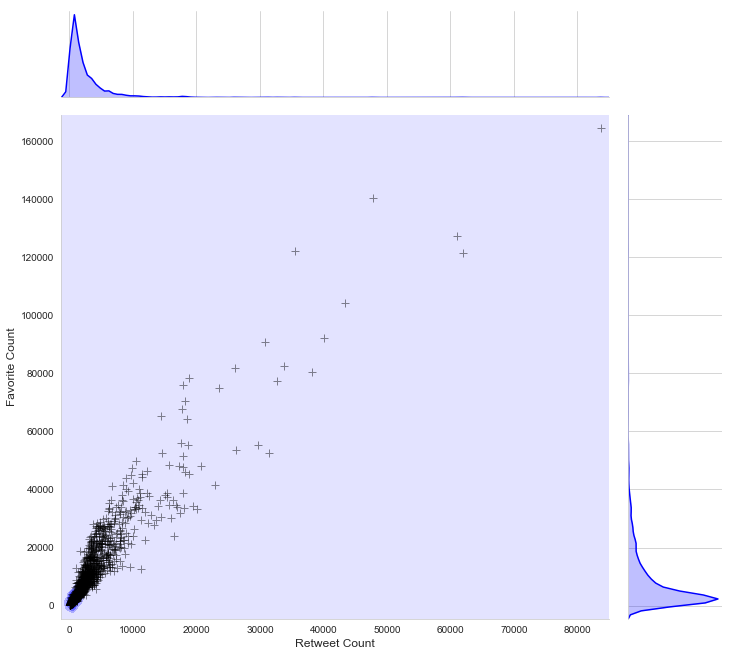

```python
import seaborn as sns
sns.set_style('whitegrid')
g = sns.jointplot(x="retweet_count",
                  y="favorite_count",
                  data=final_master,
                  color="blue",
                  kind="kde",
                  size=10)
g.plot_joint(plt.scatter,
             c="black",
             s=80,
             linewidth=1,
             marker="+",
             alpha=0.45)
g.set_axis_labels("Retweet Count", "Favorite Count",fontsize=12)

g.fig.subplots_adjust(top=0.9)
```

There is strong correlation between retweet_count and favourite count below 10, 000 retweeted_count. Then the correclation started weaken from 10, 000 onwards.